# Your Digest for Monday, Feb 19, 2024 11:59 PM

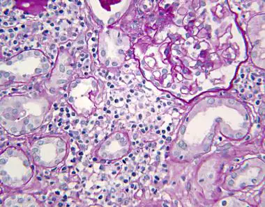

(note mononuclear interstitial infiltrate with normal glomerulus above)

```
- Can present with **proteinuria** if the disease is **NSAID** induced. (nephrotic syndrome in AIN is unique to NSAID induced AIN).
```

(TRPV6 is in the gut)

- Lepto MAT is good but falling out of favour
- **IgM ELISA is the gold standard test**
- Apparently MAT is more specific but *less sensitive* than the IgM ELISA.  
  (Other organisms cause lepto in animals)  
  #2017BSQ-APR/Q01

[figure not shown]

- But DG microscopy has **very low sensitivity and specificity** -> so not used as a confirmatory test.
- ChatGPT: Darkfield microscopy can potentially show positive results in leptospirosis infection during the early stages of the disease, typically within the first week of illness.
- **"Question mark" hook** on bacterium - characteristic feature.
- CSF - CSF PCR **will not show** leptospira antigen in leptospira meningitis because the meningitis is **aseptic** - **it's immune mediated.**
- **MAT** is a method to detect antibodies in patient serum.
  - MAT **detects antibodies to specific serovars** using live leptospiral antigens.
  - The reported titer is the last dilution that produces 50% agglutination is the reported titre.

# Japanese encephalitis

> With the near eradication of poliomyelitis, JEV is now the leading cause of childhood viral neurological infection and disability in Asia
- Ticagrelor -> can cause transient dyspnoea due to impairment of adenosine impairment during initial treatment.

```
    - **NSAIDS** can reduce sodium excretion (through prostaglandin inhibition) so avoid in ascites.
```

### Preference of prescription of drugs in heart failure (HFpEF)

- [Source](https://www.msdmanuals.com/professional/cardiovascular-disorders/heart-failure/drugs-for-heart-failure)  
  **Beta blockers**
- HFrEF: To be used in all patients with HFrEF unless contraindicated
- HFpEF: *No clear benefit*.  
  **ACE inhibitors**
- All patients with HFrEF should be given ACE inhibitors.  
  **Aldosterone receptor angatonist (Spironolactone)**
- HFrEF: ARA + ACEi or ARA + ARB are the preferred combinations
- HFpEF: Spironolactone reduces hospitalizations and probably mortality.  
  **Angiotensin receptor blockers (ARB): (Losartan)
- HFrEF: Not demonstrably superior to ACE inhibitors but have less incidence of cough and angiooedema.
- HFpEF: "ARBs *should be used in HFpEF only if* they are already being used to treat hypertension, diabetic kidney disease, or microalbuminuria"  
  **ARNI** (Sacubitril valsatan):
- Should be stated on all patients with stable HFrEF (**particularly those with NYHA II or III symptoms** and who have elevated BNP levels before treatment).
- Because neprilysin inhibitors increase BNP levels, **NTproBNP levels (which are not increased by the drug) should be used instead** to help diagnose and manage HF.

**SGLT-2** inhibitors

- Dapagliflozin and empagliflozin are the best studied.
- Can be used "across the ejection fraction spectrum". [Source](https://www.ncbi.nlm.nih.gov/pmc/articles/PMC10172076/)

**MRA**: Diuretic and BP lowering effects + blockage of deleterious effects of aldosterone on the heart.

> *Because **aldosterone can be produced independently** of the renin-angiotensin system*, its adverse effects are not inhibited completely even by maximal use of ACE inhibitors and angiotensin II receptor blockers.  
> [!TIP] Mnemonic: first line drugs for heart failure => **RBMS** **BARS**
> - Beta blockers (C,B,M)
> - Aldosterone Angatonist (Spironolactone)
> - Rening antiogensin system inhibitors (Captopril / Losartan)
> - SGLT-2 inhibitors

#2017BSQ-APR/Q02

NSAID mediated kidney injury can occur in several ways.

**Haemodynamically mediated NSAID induced kidney injury**